# McKeegan-hw5-DataVis-ggplot

Kelli McKeegan

DUE: Thursday, March 25

#### Necessary items:

- **libraries:** tidyverse, ggsci, ggforce, patchwork, Hmisc
- **files:** bloom_df.csv, hw_task2_blank.png

Within RStudio you can directly edit these blocks of code and turn in your homework that way with your code and figures printed.  
I **HIGHLY** recommend getting your code to work in a normal R script then just copy and pasting the final code over to this document

**First: import libraries, set your working directory, and read in bloom_df**

```r
library(tidyverse)
library(ggforce)
library(ggsci)
library(patchwork)
library(Hmisc)
library(wesanderson)

setwd('/Users/kelli/BIOL792/part2_sp21/Data_Science_For_Biology_II/Part.3_DataVisualization/1-ggplot')

bloom_df <- read.csv('bloom_df.csv')
```

### bloom_df contents

- **taxa:** genus_species
- **genus**
- **species**
- **logbodysize**
- **trophic_position**
- **reg:** diadromous or non-diadromous

Let’s take a peak and look at the structure

```r
bloom_df[1:5,]
```

```
##                   taxa genus        species logbodysize trophic_position
## 1       Alosa_alabamae Alosa       alabamae    1.707570        0.4313638
## 2          Alosa_alosa Alosa          alosa    1.778151        0.5563025
## 3         Alosa_fallax Alosa         fallax    1.778151        0.5563025
## 4      Alosa_mediocris Alosa      mediocris    1.778151        0.6127839
## 5 Alosa_pseudoharengus Alosa pseudoharengus    1.602060        0.5440680
##          reg
## 1 diadromous
## 2 diadromous
## 3 diadromous
## 4 diadromous
## 5 diadromous
```

```r
str(bloom_df)
```

```
## 'data.frame':    50 obs. of  6 variables:
##  $ taxa            : Factor w/ 50 levels "Alosa_alabamae",..: 1 2 3 4 5 6 7 8 9 10 ...
##  $ genus           : Factor w/ 34 levels "Alosa","Amazonsprattus",..: 1 1 1 1 1 1 2 3 3 3 ...
##  $ species         : Factor w/ 48 levels "aestuaria","alabamae",..: 2 3 19 31 36 39 41 11 13 14 ...
##  $ logbodysize     : num  1.71 1.78 1.78 1.78 1.6 ...
##  $ trophic_position: num  0.431 0.556 0.556 0.613 0.544 ...
##  $ reg             : Factor w/ 2 levels "diadromous","non-diadromous": 1 1 1 1 1 1 2 2 2 2 ...
```

### Graphical tasks

This next tasks are going to ask you to make a series of figures. For each one, I would like you to make all of them *look good*. Change the theme around, change the axis labels, etc. Additionally, each of these will use the **reg** column which has 2 factors. Change the color and/or shape of them both.

### Task 1: Continuous vs. continuous plot

Create two scatterplots of logbodysize vs. trophic_position grouped by reg

##### First plot:

- a 2 trend lines (method = ‘lm’), one for each reg variable

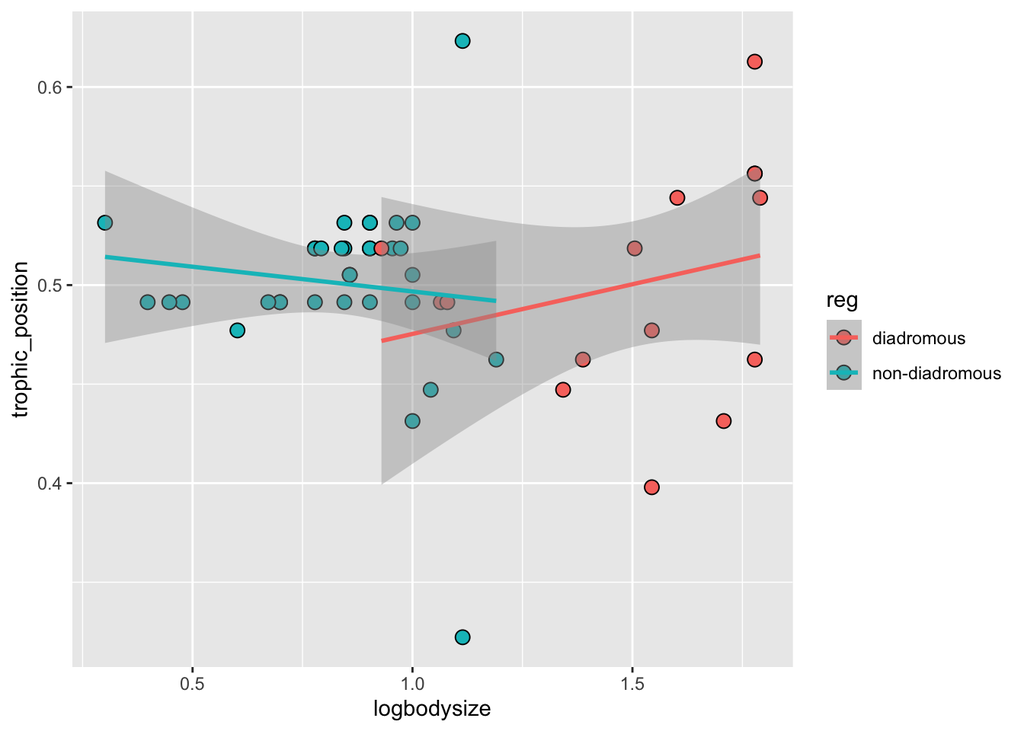

```r
#plot 1.1
ggplot(data=bloom_df,aes(x=logbodysize,y=trophic_position,colour=reg)) +
  #starting simple I guess because I'm scared
  geom_point(aes(fill=reg),size=3,pch=21,colour='black') +
  stat_smooth(method='lm')
```

##### Second plot

- a single trend line for the whole model

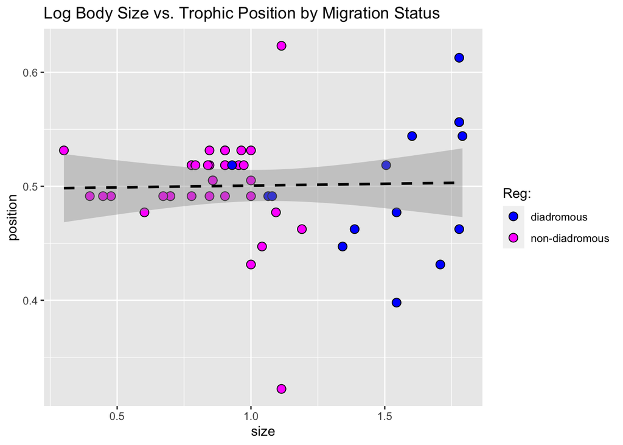

```r
#plot 1.2
ggplot(data=bloom_df,aes(x=logbodysize,y=trophic_position,colour=reg)) +
  geom_point(aes(fill=reg),size=3,pch=21,colour='black') +
  #simple again, point size 3 and the black outlines because I think they look clearer
  #somehow these other instructions or something else made it just one trendline?
  stat_smooth(method='lm',linetype='dashed',colour='black') +
  #let's do some fun colours
  scale_fill_manual(name='Reg:',values=c('blue','magenta')) +
  #and practice doing labels & a title
  xlab('size') + ylab('position') +
  ggtitle('Log Body Size vs. Trophic Position by Migration Status')
```

### Task 2: Continuous vs. categorical

##### The layout will be:

- 2 panels: trophic_position and logbodysize
- x axis: reg
- y axis: value of trophic_position and logbodysize

##### Create 4 plots:

- bar and error bars (mean and 95% conf. int.)
- point and error bars (mean and 95% conf. int.)
- box plots
- raw data + point and error bars (mean and 95% conf. int.)

All these plots should have the same general layout but change the type of plot to visualize the data.

**HINT:** logbodysize and trophic_position need to be turned into long format

##### Example layout:

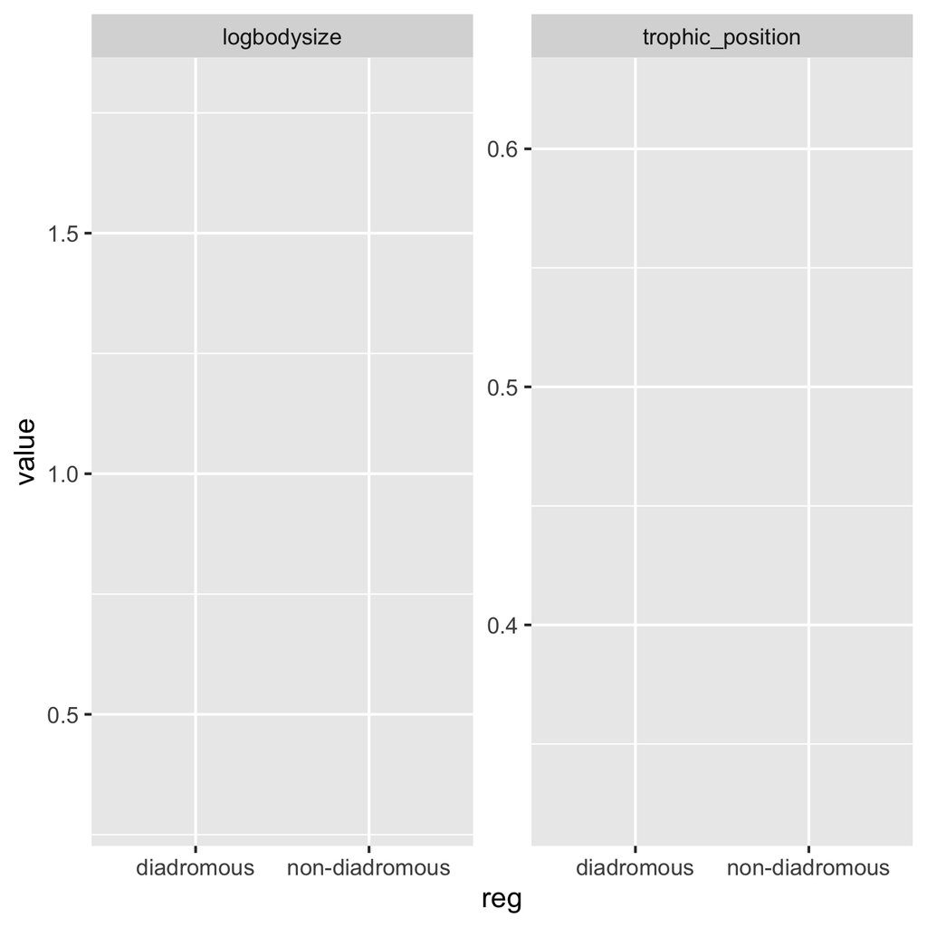

sample layout for task2

```r
#making longbodysize & trophic_position into long format
#using gather - built-in ggplot function, quicker than rbind?
bloom_long_df <- bloom_df %>%
  gather(key=characters,value=mean,c(logbodysize,trophic_position))
```

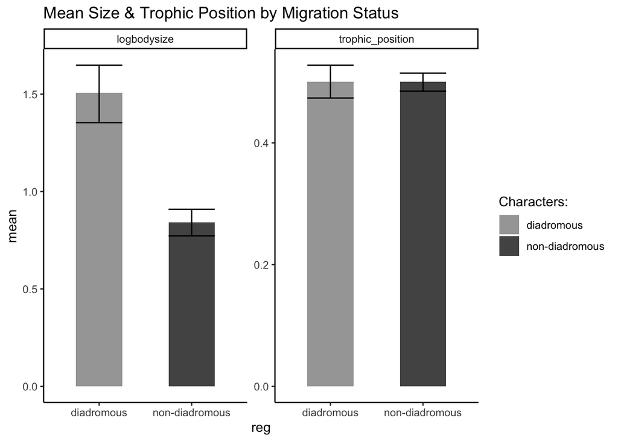

```r
#plot 2.1
#bar and error bars (mean and 95% conf. int.)
#using the code from the "very bad plot" but hopefully it won't be super bad?
ggplot(data=bloom_long_df,aes(x=reg,y=mean,fill=reg)) +
  #scaling is unique to data; bar graph using built-in stats
  facet_wrap(~characters,nrow=1,scales = 'free') +
  stat_summary(fun = mean, geom = "bar", width = 0.5) +
  #adding error bars... not sure wht all the fun is and the mean_cl_boot?
  stat_summary(fun.data = mean_cl_boot, geom = "errorbar",color='black', width =0.5) +
  #just going to do gray for this one
  scale_fill_manual(name='Characters:',values=c('gray65','gray33')) +
  ggtitle('Mean Size & Trophic Position by Migration Status') +
  #no yucky gray background
  theme_classic()
```

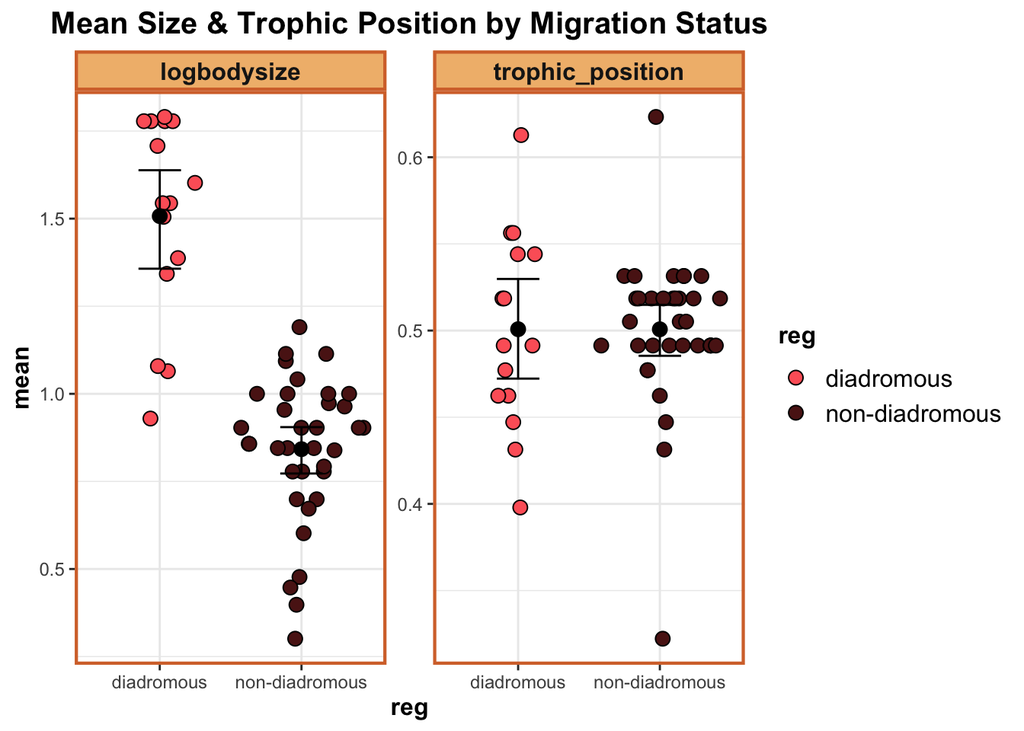

```r
#plot 2.2
#point and error bars (mean and 95% conf. int.)
gb1 = wes_palettes$GrandBudapest1
ggplot(data=bloom_long_df, aes(x=reg,y=mean,fill=reg)) +
  facet_wrap(~characters,nrow=1,scales = 'free') +
  geom_sina(size=3,pch=21) +
  stat_summary(fun.data = mean_cl_boot, geom = "errorbar",color='black',width = 0.3,size=0.5) +
  stat_summary(fun = mean, geom = "point",size=3,colour='black',fill='white') +
  scale_fill_manual(values = gb1[2:3]) +
  ggtitle('Mean Size & Trophic Position by Migration Status') +
  #no yucky gray background
  #I kind of like the grids for this since the points are staggered
  theme_bw() +
  theme(#title in center
        plot.title = element_text(size = 15, colour="black",face = "bold",hjust=0.5),
        axis.text = element_text(size=9),
        axis.title = element_text(size = 12, colour="black",face = "bold"),
        #idk I'm just Wes Anderson-ing out now
        panel.border = element_rect(size = 1.5, colour = gb1[4]),
        legend.title = element_text(size = 12, colour="black",face = "bold",vjust = 1),
        legend.text = element_text(size=12),
        strip.text.x = element_text(size=12, face="bold"),
        strip.background = element_rect(size=1.5,colour=gb1[4],fill=gb1[1]))
```

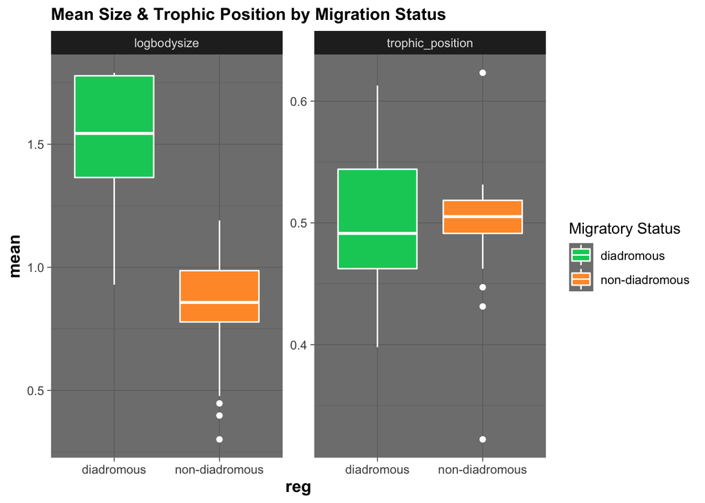

```r
#plot 2.3
#box plots - again, using the code for "eh, bad" so hopefully this comes out alright
ggplot(data=bloom_long_df, aes(x=reg,y=mean,fill=reg)) +
  facet_wrap(~characters,nrow=1,scales = 'free') +
  geom_boxplot(color="white") +
  #want to put a title on the legend, and playing with hexadecimal colors now
  scale_fill_manual(name='Migratory Status',values=c('#00CC66','#FF9933')) +
  ggtitle('Mean Size & Trophic Position by Migration Status') +
  #playing with different themes - this one is kinda wild
  theme_dark() +
  theme(plot.title = element_text(size = 12, colour="black",face = "bold"),
        axis.title = element_text(size = 12, colour="black",face = "bold"))
```

```r
  #SOOO not friendly to the eyes but I'm having fun
  #gearing up for the bad-figure olympics
```

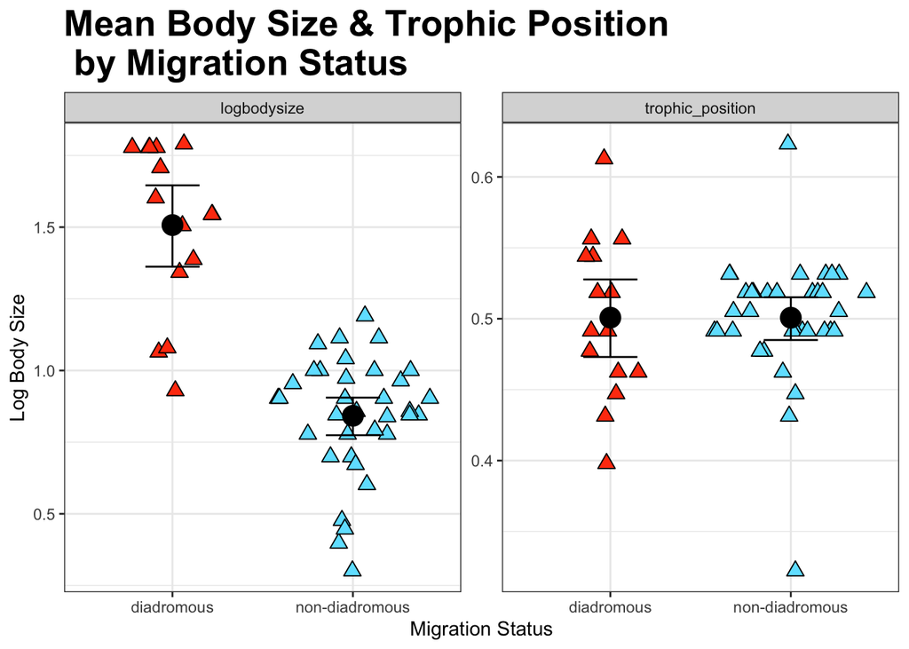

```r
#plot 2.4
#raw data + point and error bars (mean and 95% conf. int.)
#for my next trick, I'll use code from the "okay" plot and try to make it okay-er
ggplot(data=bloom_long_df,aes(x=reg,y=mean,fill=reg)) +
  facet_wrap(~characters,nrow=1,scales = 'free') +
  geom_sina(size=3,pch=24) +
  scale_fill_tron() +
  stat_summary(fun.data = mean_cl_boot, geom = "errorbar",color='black',width = 0.3) +
  stat_summary(fun = mean, geom = "point",size=5,colour='black') +
  ggtitle('Mean Body Size & Trophic Position \n by Migration Status') +
  #still not really sure what diadromy is so sorry if it's not migration status?
  xlab("Migration Status") + ylab("Log Body Size") +
  theme_bw() +
  theme(legend.position='none',
        plot.title = element_text(size = 20, colour="black",face = "bold"))
```

```r
#these are alright... but I'll tweak a little for my better figure below
```

### Task 3: layering your plots

Make any two figures with the bloom_df! Can be something we’ve done or something completely different. Make one TERRIBLE figure and one GREAT figure.

Put them together using *patchwork* or *ggarrange*

```r
#plot 3 - terrible
terrible <- ggplot(data=bloom_long_df,aes(x=reg,y=mean,fill=reg)) +
  #no scales=free for some extra wacky
  facet_wrap(~characters,nrow=1) +
  stat_summary(fun = mean, geom = "bar") +
  stat_summary(fun.data = mean_cl_boot, geom = "errorbar",color='black') +
  #looked up colors that people with color blindess might not distinguish between
  scale_fill_manual(values=c('#339999','#9966CC')) +
  ggtitle('Terrible Plot Showing logbodysize and trophicposition based on diatromous vs. non-diatromous') +
  theme_dark()
  theme(legend.position='none',
        plot.title = element_text(size = 20, colour="black",face = "bold"))
```

[output not shown]

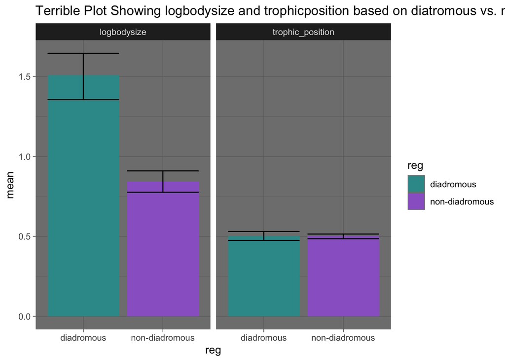

```r
terrible
```

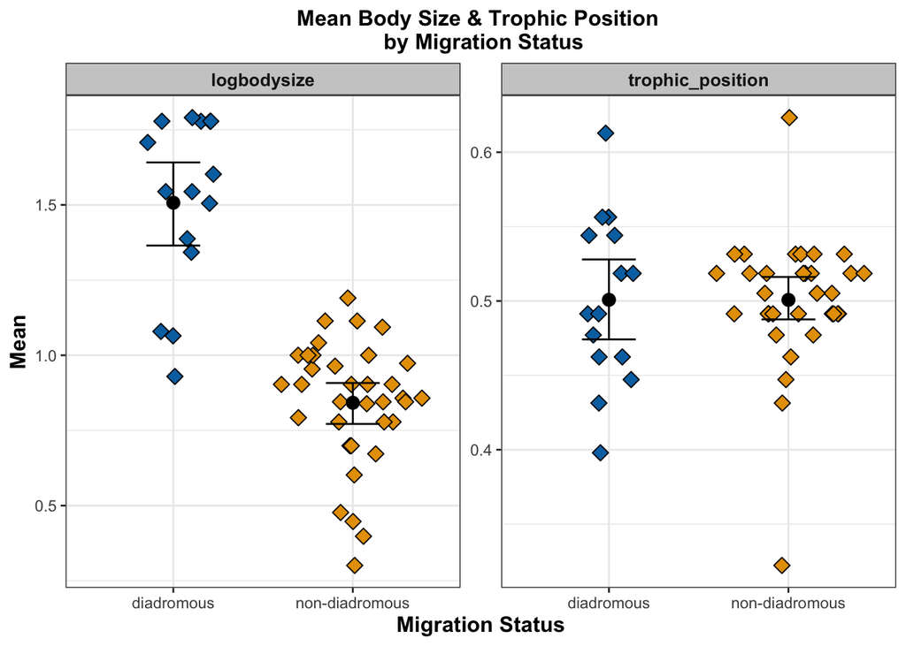

```r
#making a color-blindness-friendly palette
cbbPalette <- c("#000000", "#E69F00", "#56B4E9", "#009E73", "#F0E442", "#0072B2", "#D55E00", "#CC79A7")

#plot 3 - better plot
#again not sure my eye is trained enough to know what is GREAT
iwouldntsayitsgreat <- ggplot(data=bloom_long_df,aes(x=reg,y=mean,fill=reg)) +
  facet_wrap(~characters,nrow=1,scales = 'free') +
  geom_sina(size=3,pch=23) +
  scale_fill_manual(values=cbbPalette[c(6,2)]) +
  stat_summary(fun.data = mean_cl_boot, geom = "errorbar",color='black',face="bold", width = 0.3) +
  stat_summary(fun = mean, geom = "point",size=3,colour='black') +
  ggtitle('Mean Body Size & Trophic Position \n by Migration Status') +
  #still not really sure what diadromy is so sorry if it's not migration status?
  xlab("Migration Status") + ylab("Mean") +
  theme_bw() +
  theme(legend.position='none',
        plot.title = element_text(size = 12, colour="black",face = "bold", hjust=0.5),
        axis.title = element_text(size = 12, colour="black",face = "bold"),
        strip.text.x = element_text(size=10, face="bold"),
        strip.background = element_rect(colour="#333333",fill="#CCCCCC"))
iwouldntsayitsgreat
```

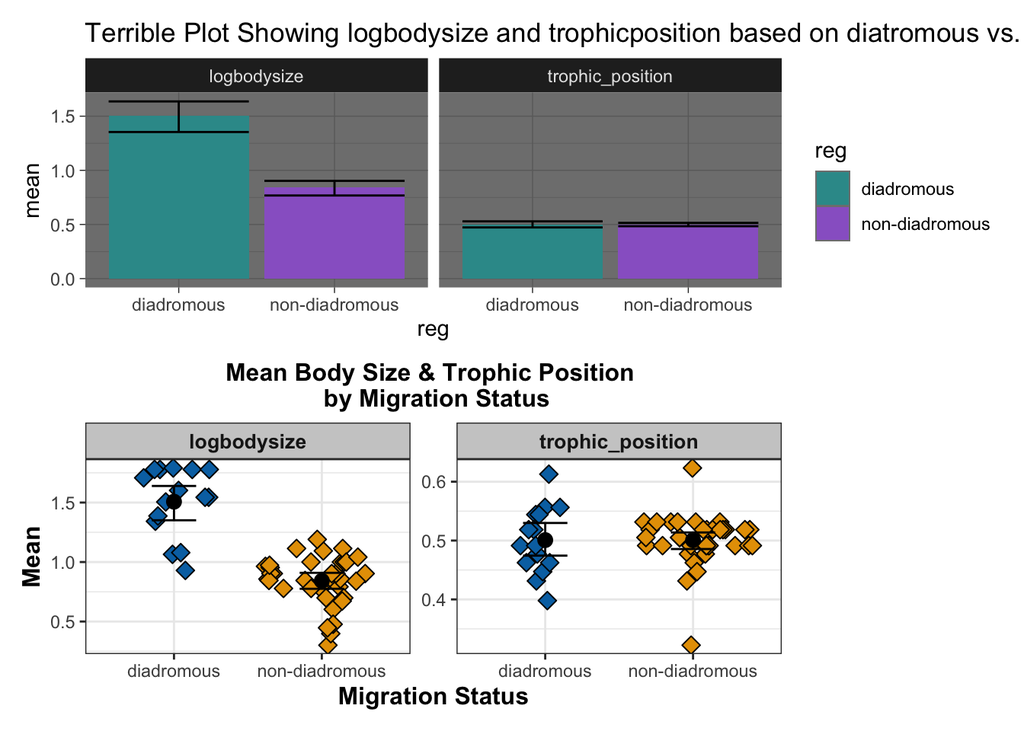

```r
#putting them together, I want one on top of the other
terrible + iwouldntsayitsgreat + plot_layout(ncol=1)
```

```r
#might need a little help on layout since they're squished?
```